# Data Summary for Project Magnesium

M Wilson

23/11/2019

# Introduction

Serum magnesium concentration is a commonly measured blood test performed on patients admitted to intensive care.

The normal serum range is 0.6 to 1.0 mmol/L (1.5 - 2.4 mg/dL) as reported from the University College London Hospital Laboratory Service.

Magnesium is the fourth most abundant cation in the body. Predominantly concentrated intracellularly it is responsible for enzyme processes, DNA and cell membrane stabilisation and regulation of cardiac and smooth muscle tone. Specifically at the myocardial level it regulates the activity of the sodium/potassium ATPase pump.

Previous studies of serum magnesium in intensive care have suggested the majority of patients to be magnesium deficient (<0.6 mmol/L) via multiple aetiologies.

Magnesium is also frequently supplemented in ICU to maintain normal, or occasionally supra-normal serum concentrations. This is in response to a range of provoking factors:

- Prevention of abnormal cardiac rhythms (e.g. Atrial Fibrillation, AF)
- Treatment of abnormal cardiac rhythms (e.g. AF or Torsades de Pointes)
- Treatment of eclampsia
- Treatment of moderate-severe exacerbations of asthma
- Treatment of hypokalaemia

It is a commonly held belief that magnesium supplementation in a critical care setting is efficacious as prophylaxis against developing de novo atrial fibrillation.

This belief stems from a plausible biological mechanism of action, in addition to multiple observational studies and randomised controlled trials.

## Existing Literature

**Meta-Analyses**

1. Intravenous magnesium prevents atrial fibrillation after coronary artery bypass grafting: a meta-analysis of 7 double-blind, placebo-controlled, randomised trials, 2012.

Pooled analysis showed significantly reduced postoperative AF (RR 0.64) with magnesium treatment with no heterogeneity.

**Systematic Reviews**

1. Interventions for preventing postoperative atrial fibrillation in patients undergoing heart surgery, Cochrane Review, 2013.

21 RCTs of 2988 patients undergoing cardiac surgery. All mg dosing IV but dosing varied, half studies had intra-op magnesium.

Pooled analysis showed significantly reduced postop AF in treatment group (16.5%) vs. control (26.2%), OR 0.55.

**Randomised Controlled Trials**

1. Effects of intravenous magnesium sulphate in suspected acute myocardial infarction on acute arrhythmias and long term outcome, 1995.

**Literature Reviews**

1. New-onset atrial fibrillation in adult patients after cardiac surgery, 2019.

Incidence of AF after non-cardiac surgery estimated between 1 and 15% (10-30% for thoracic surgery, 25-50% after cardiac surgery).

Good data that postop AF is associated with badness (stroke, infection, GI and renal dysfunction, increased short and long term morbidity and mortality, increased length of hospital stay).

Multifactoral pathogenesis. Risk factors for atrial stretch include hypertension, myocardial ischaemia, valvular dysfunction such as mitral regurgitation. Postop pro-arrhythmogenic factors include increased endogenous catecholamines, inflammatory and oxidative mediators, plus the use of exogenous catecholamines.

More general risk factors: - History of PAF - Obesity - COPD - Chronic renal failure - Rheumatic heart disease - Male gender - Age

In cardiac surgery two periods of increased risk have been identified, immediate (zero hour to first 18 hours postop) and delayed (24-48 hours).

**Observational**

1. Low serum magnesium and the development of atrial fibrillation in the community: The Framingham Heart Study, 2013.

In their retrospective analysis of 3530 patients from the Framingham Offspring Study, Khan et al found a moderate association between hypomagnesaemia and subsequent development of atrial fibrillation (adjusted HR 1.52, 1.00 - 2.31, P = 0.05).

2. Are serum magnesium and potassium levels associated with atrial fibrillation following cardiac surgery? 2019.

In this observational cohort study, Howitt et al reviewed heart rhythm data for 3068 post cardiac surgery patients. The incidence of AF was 17.8%. After adjusting for logistic EuroScore, operation type, bypass time and age they found potassium < 4.5 associated with AF (OR 1.43), mean magnesium < 1 was not associated with AF, but administration of magnesium was associated with increased risk of developing AF.

3. Potassium and magnesium supplementation do not protect against atrial fibrillation after cardiac surgery: a time-matched analysis, 2016.
4. Database evaluation of the association between serum magnesium levels and the risk of atrial fibrillation in the community, 2015.
5. Association of serum magnesium on mortality in patients admitted to the intensive care unit, 2017.

Summary of Existing Literature

| Study | Journal | Year | Type | Design | Population | Findings |
| --- | --- | --- | --- | --- | --- | --- |
| Khan et al | Circulation | 2013 | Observational | Retrospective Cohort | Community, US | Low magnesium associated with developing AF in the community |
| Howitt et al | Journal of Cardiothoracic and Vascular Anesthesia | 2019 | Observational | Retrospective Cohort | Post Cardiac Surgery, UK | Potassium < 4.5 associated with AF; mean Mg < 1 not associated with AF; administering Mg associated with AF |
| Lancaster et al | Annals of Thoracic Surgery | 2016 | Observational | Retrospective Case-Control: Time-Matched Analysis | Post Cardiac Surgery, US | Higher potassium and magnesium associated with AF; magnesium independent predictor of AF in multivariate analysis; magnesium supplementation associated with increased AF. |
| Markovits et al | International Journal of Cardiology | 2015 | Observational | Retrospective Cohort | Community, Israel | Increased AF associated with mild and moderate hypomagneseaemia, not time-dependent suggesting non-causal relationship |
| Naksuk et al | American Journal of Medicine | 2017 | Observational | Retrospective Cohort | Cardiac Care Unit (Medical), US | Increased mortality associated with Mg > 1.2 in multivariate analysis |
| Arsenault et al | Database of Cochrane Reviews | 2013 | Systematic Review | Cochrane Review | Post Cardiac Surgery | Significantly decreased postoperative AF with treatment vs. control |
| Gu et al | Trials | 2012 | Meta-Analysis | Meta-Analysis | Post Coronary Artery Bypass Grafting | Significantly decreased postoperative AF with magnesium with minimal heterogeneity between trials |

## Aims

1. Describe the epidemiology of serum magnesium in a general ICU patient cohort
2. Describe the possible association between AF and serum magnesium
3. Describe practice preferences for magnesium replacement based on varying serum magnesium concentrations
4. Derive the causal impact of supplemental magnesium administration on prophylaxis of AF in this population

# Data Sources

The Philips ICIP database was interrogated for serum magnesium lab measurements, magnesium administration and nurse identifier data.

The CCHIC database was used to extract data pertaining to the following:

- Age at admission
- Sex
- Length of stay
- Admission classification
- Illness severity by APACHE score
- CPR in 24 hours prior to admission
- Unit mortality
- Heart rhythm
- Heart rate
- Serum potassium lab and point of care measurements
- Serum pH, bicarbonate, arterial carbon dioxide from point of care measurements
- Serum Creatinine

# Pipeline

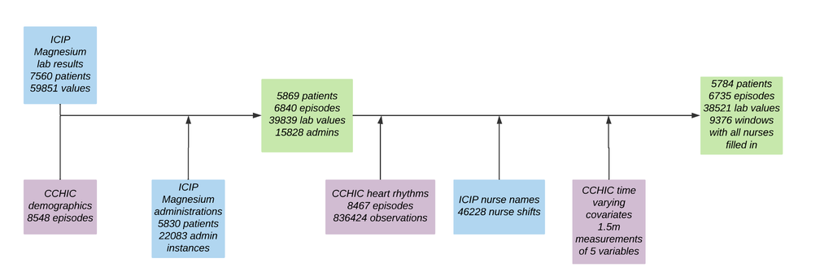

# Data Summary

## Exclusion Criteria

Patients < 18 years old on admission were excluded.

Additional exclusion criteria were applied specific to each analysis as detailed below.

The final joined data consists of 38,222 observations of 5739 individual patients (as determined by unique patient identity numbers), across 6675 distinct episodes (as defined by unique CCHIC episode identity numbers). There were 6776 distinct episodes defined using ICIP episode identity numbers.

The distribution of number of episodes per patient can be seen below.

Number of Episodes Per Patient

| Number of Episodes | Number of Patients |
| --- | --- |
| 1 | 5030 |
| 2 | 561 |
| 3 | 103 |
| 4 | 26 |
| 5 | 10 |
| 6 | 6 |
| 7 | 1 |
| 8 | 1 |
| 9 | 1 |

## Missing Data

The proportion of missing data for each variable in the final data table can be seen below, described per patient.

Missing Data Per Episode

| Variable | Count | Percentage |
| --- | --- | --- |
| Age | 0 | 0.00 |
| Sex | 1 | 0.01 |
| Length of Stay | 0 | 0.00 |
| Admission Type | 0 | 0.00 |
| APACHE Score | 37 | 0.55 |
| CPR in Prev. 24 hours | 2 | 0.03 |
| Unit Mortality | 0 | 0.00 |
| Potassium at Magnesium Measurement | 1423 | 21.00 |
| Creatinine at Magnesium Measurement | 1235 | 18.23 |
| pH at Magnesium Measurement | 2531 | 37.35 |

## Sample Characteristics

The summary of all the covariates is conducted at the episode level or for individual magnesium windows created.

### Age

The sample age range was 18 to 103 years old. The median age was 64 (52.5 - 75.5).

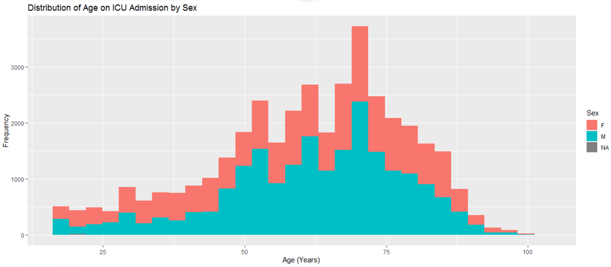

### Sex

Distribution of Sex

| sex | count | prop |
| --- | --- | --- |
| F | 2929 | 51.0367660 |
| M | 2809 | 48.9458094 |
| NA | 1 | 0.0174246 |

### Length of Stay

The median length of stay per episode was 2.3 days (0.3 - 4.3).

Length of Stay (Days) by Sex

| sex | median_los | iqr_los |
| --- | --- | --- |
| F | 2.19 | 3.65 |
| M | 2.55 | 4.89 |

### Admission Type

Admissions were classified as planned medical or surgical and ‘other’. ‘Other’ is a composite of unplanned local admissions or transfers, planned transfers and repatriations.

There were 85 episodes labelled as planned medical admissions, 2460 planned surgical episodes and 4130 episodes of admission type ‘Other’.

Categorised Admission Type

| type | count | prop |
| --- | --- | --- |
| Medical | 85 | 1.254427 |
| Surgical | 2460 | 36.304605 |
| Other | 4130 | 60.950413 |

### APACHE Score

Severity of illness was estimated by admission APACHE score. This was absent for 37 episodes. The median APACHE score per episode was 16 (12 - 20). This was the same for males and females.

### CPR Pre-Admission

In addition, whether the patient underwent CPR in the 24 hours preceding admission was also recorded. Two patients were missing CPR data.

CPR in 24 hours prior to admission

|  | CPR | No CPR | Missing |
| --- | --- | --- | --- |
| Female | 77 | 3288 | 1 |
| Male | 103 | 3204 | 1 |

## Magnesium

The distribution of serum magnesium measurements on first arrival to ICU is described below. The admission serum magnesium is defined as the first recorded magnesium lab measurement associated with the episode following the final joining process.

For reference the join was defined such that magnesium measurements associated with the episode ID were joined to that episode, occurring up to 12 hours prior to the episode start time identified in the CCHIC data. This was to allow initial magnesium measurements occurring prior to admission but still influencing decisions taken during the admission to be captured. For reference, 97% of episodes had their first serum magnesium measurement recorded within 24 hours of the episode start.

The mean serum magnesium on admission per episode was 0.80 mmol/L (sd, 0.21). There was minimal difference between men and women (female mean 0.79, male 0.81) and serum magnesium on admission stayed relatively consistent across age range and APACHE score.

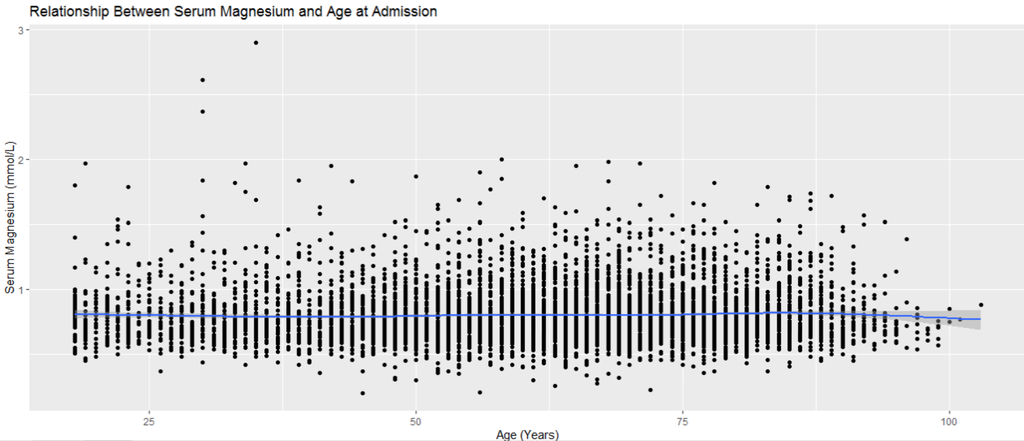

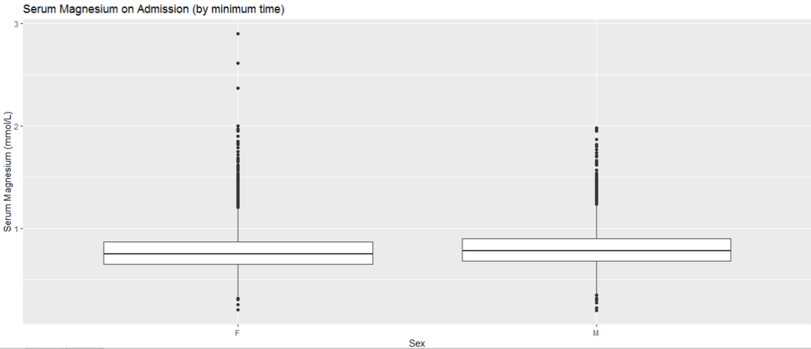

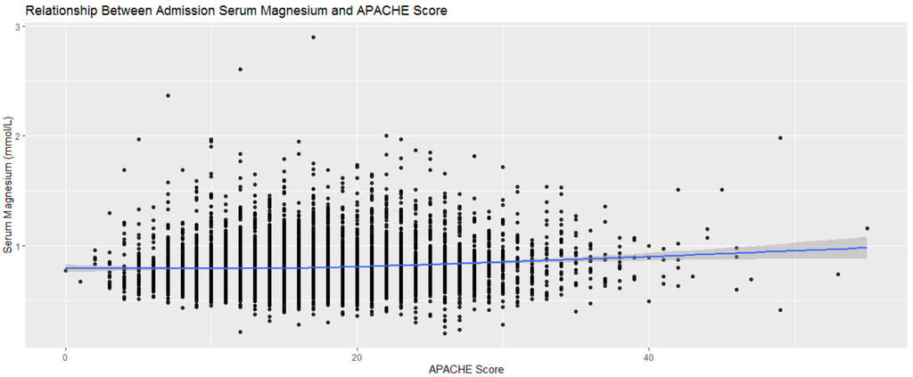

The mean serum magnesium value across the duration of the episode was 0.89 mmol/L (sd, 0.15).

The mean change in serum magnesium value across each episode was -0.11 mmol/L (sd, 0.27).

When stratified by unit mortality, patients who survived had an average serum magnesium of 0.79 mmol/L versus 0.87 in those who died.

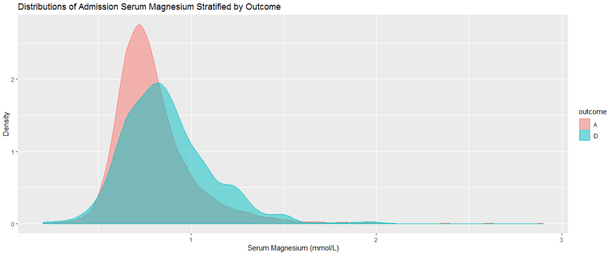

The median number of serum magnesium measurements per episode was 3 (1 - 5).

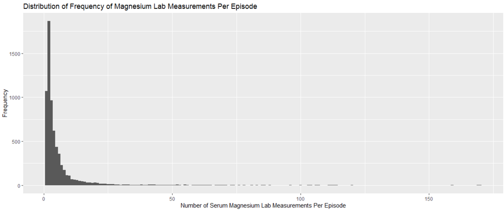

The timing of recorded serum magnesium measurements was predominantly concentrated in the morning.

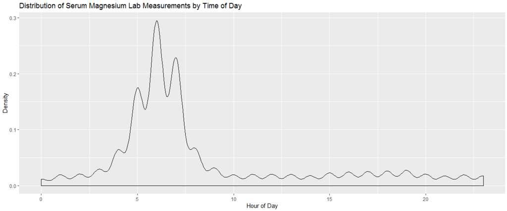

The median number of administrations per episode was 1 (0 - 2), with a range of 0-76 administrations per episode.

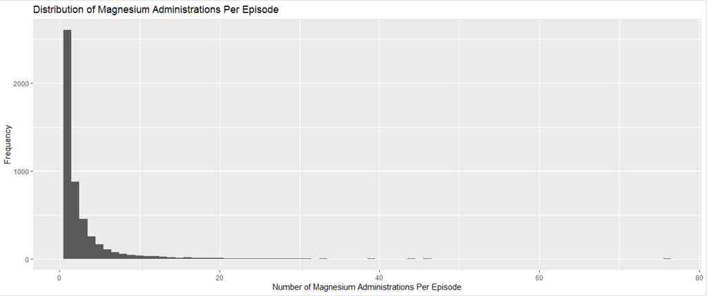

The timing of magnesium administrations was predominantly concentrated around mid-morning.

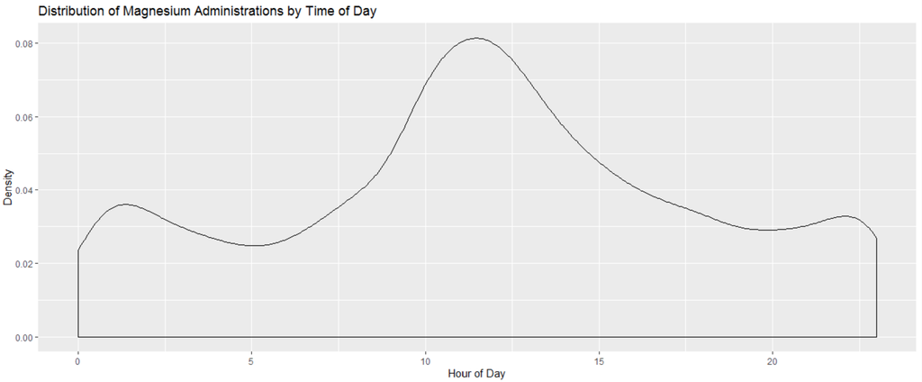

Stratifying serum magnesium measurements by subsequent magnesium administration confirms that magnesium supplementation more commonly occurs predominantly at levels < 1.0 mmol/L.

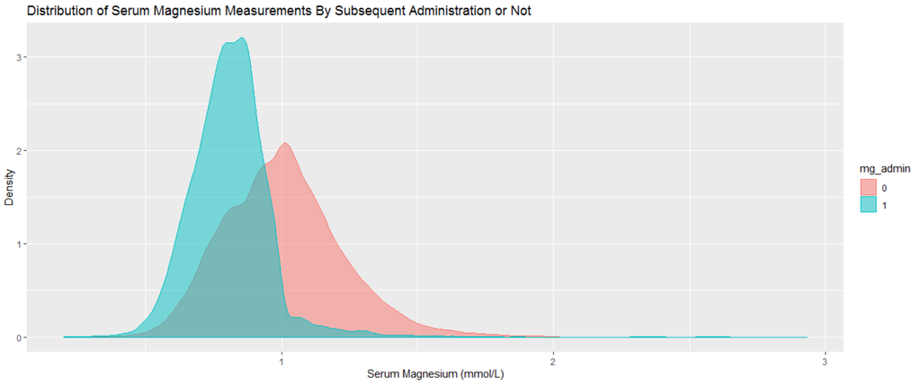

## Potassium

Potassium closest to the serum magnesium lab measurement was extracted from potassium lab measurements. Where two measurements existed equally distant from the magnesium measurement, the mean was taken.

There were missing potassium values for 1423 episodes (21%) and 1652 magnesium windows (4.3%).

The mean potassium for each episode was 4.46 mmol/L (sd, 0.43).

The mean potassium for each magnesium window was 4.55 mmol/L (sd, 0.55). The mean potassium for each magnesium window where magnesium was subsequently administered vs. where it was not administered was similar at 4.48 (sd, 0.51) vs. 4.60 (sd, 0.56).

The mean potassium closest to the first AF episode in a window (up to three hours preceding event) was 4.35 (sd, 0.52).

The mean potassium at the time of magnesium administration (up to three hours preceding event) was 4.14 (sd, 0.51).

## Creatinine

Creatinine closest to each serum magnesium lab measurement was extracted.

There were missing creatinine values for 1235 episodes (18.2%) and 2428 magnesium windows (6.4%).

The mean creatinine across all the magnesium windows was 105 mmol/L.

## pH

Venous or arterial pH closest to each magnesium lab measurement was extracted.

There were missing pH values for 2531 episodes (37%) and 3873 magnesium windows (10.1%).

The mean pH across all the magnesium windows was 7.38 (sd, 0.07).

## Atrial Fibrillation

The mean serum magnesium at the start of the magnesium window for windows with no AF events was 0.93 mmol/L.

The mean serum magnesium at the start of the magnesium window for windows containing an AF event was 1.01 mmol/L.

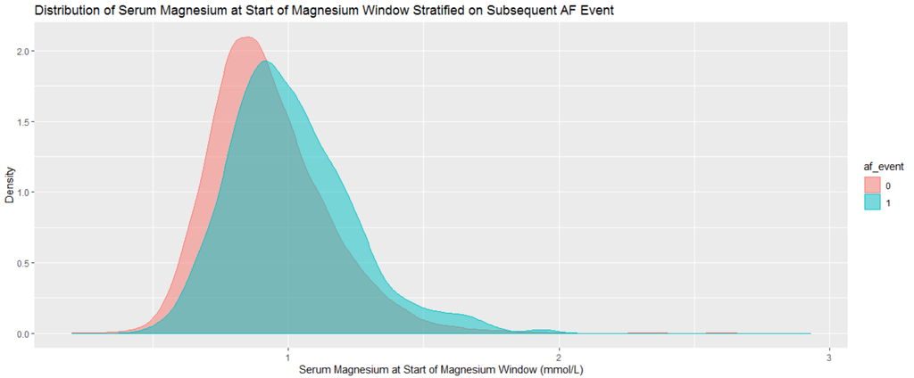

# Table 1

## Summary of Variables Per Episode

Summary of Characteristics Per Patient Episode

| Variable | Summary |
| --- | --- |
| Median (IQR) Age (Years) | 64 +/- 23 |
| Sex | Female: 51.0 |
| Median (IQR) Length of Stay (Days) | 2.3 +/- 4 |
| Admission Type | Medical: 85 (1.25%), Surgical: 2460 (36.3%), Other: 4130 (61.0%) |
| Median (IQR) APACHE Score | 16 +/- 8 |
| CPR in Prev. 24 hours (%) | 2.81 |
| Unit Mortality (%) | 9.34 |
| Mean (sd) Serum Potassium (mmol/L) | 4.46 (0.43) |
| Median (IQR) Serum Magnesium Measurements | 3 (4) |
| Mean (sd) Serum Magnesium on admission (mmol/L) | 0.80 (0.21) |
| Mean (sd) Serum Magnesium across admission (mmol/L) | 0.89 (0.15) |
| Mean (sd) Trend in Serum Magnesium across admission (mmol/L) | -0.11 (0.27) |
| Median (IQR) Magnesium Administrations | 1 (2) |

## Summary of Variables Per Magnesium Window

This is a summary of each magnesium window after applying exclusion criteria of age < 18 years old.

Summary of Characteristics Per Magnesium Window

| Variable | Summary |
| --- | --- |
| Number receiving Magnesium Administration (%) | 14,666 (38.4) |
| Median (IQR) time to Magnesium Administration (hours) | 6.42 (5.83) |
| Range of number of Magnesium Administrations | 0 - 15 (1.59% with > 1 Magnesium Administration) |
| Mean (sd) Serum Magnesium (mmol/L) | 0.93 (0.22) |
| Mean (sd) Serum Potassium (mmol/L) | 4.55 (0.55) |
| Number starting in Atrial Fibrillation (%) | 2854 (7.5) |
| Number containing an Atrial Fibrillation Event (%) | 1173 (3.1) |
| Number of Potential Treatment Events (% of total Magnesium Administrations) | 353 (2.4 of all Mg administrations) |
| Median (IQR) length of Magnesium Window (hours) | 23 (11.0) |

# Analysis

## The relationship between serum magnesium level and incidence of AF.

### Logistic regression model.

We ran a logistic regression to explore the relationship between serum magneisum level and incidence of AF. The results are displayed below.

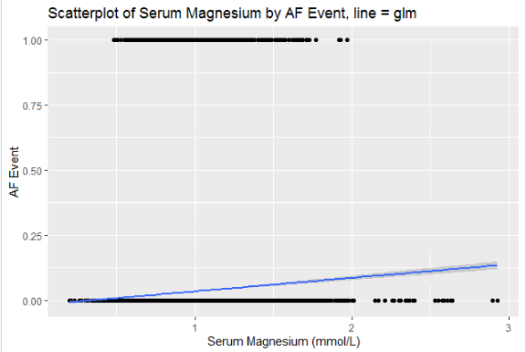

The result that a higher serum mangesium level is associated with a greater incidence of AF holds after the addition of the variables age, sex, APACHE score, serum potassium and creatinine

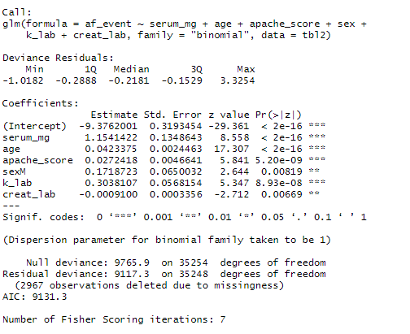

### Time to Event Analysis

We tried to further investigate the relationship between serum magneisum level and incidence of AF by performing a survival analysis as follows.

Censor variables were created, starting from the magnesium lab date for each window. All windows were censored if they reached the end of the window, defined as the minimum of the next magnesium lab measurement, the end of the episode or 24 hours. Windows were censored if magnesium was administered or the outcome occurred (AF event).

The total follow up time for each variable was create by taking the minimum of all the different censor variables.

A summary of the times to events are listed below.

```r
table3 <- tibble(
  Variable = c("Median (IQR) from mg lab measurement to first mg administration (hours)",
               "Median (IQR) time to first AF event (hours)"),
  # looks like the majority of windows are censored for 24 hours.
  # AF event defined as change from SR-> AF within mg window.
  # treatment event defined as mg_admin occurring after first af

  Summary = c("6.42 (5.83)",
              "8 (10.633)"))

kable(table3, caption = "Times to events")
```

Times to events

| Variable | Summary |
| --- | --- |
| Median (IQR) from mg lab measurement to first mg administration (hours) | 6.42 (5.83) |
| Median (IQR) time to first AF event (hours) | 8 (10.633) |

Serum magnesium was initially categorised into low vs. high (serum mg < 1, low).

```r
# surv_object <- Surv(time = tbl2$fu_time, event = tbl2$event)
# fit1 <- survfit(surv_object ~ mg_binary, data = tbl2)
# summary(fit1)
```

The results of the survival analysis are displayed below.

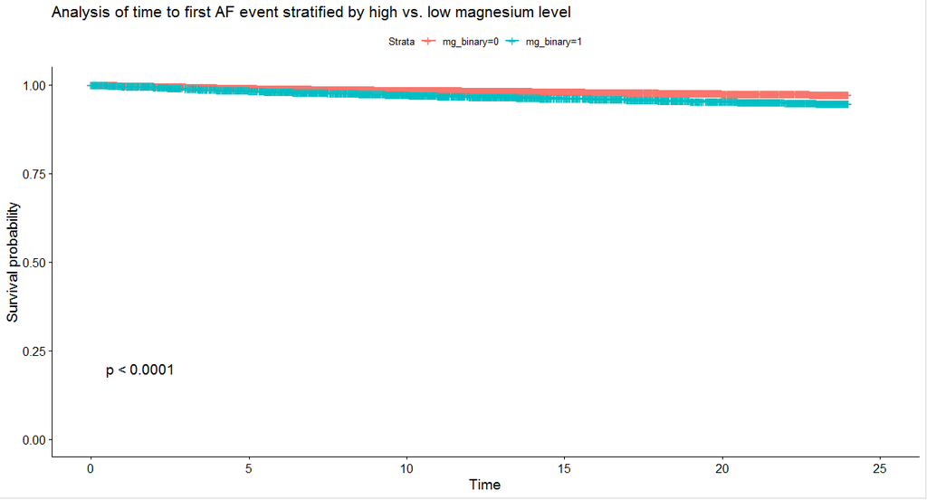

Serum magnesium was also categorised into five boundaries:

1. Less than 0.5
2. 0.5 - 0.8
3. 0.8 - 1.0
4. 1.0 - 1.2
5. Greater than 1.2

[figure not shown]

## Investigation of the causal relationship between supplementation of magneiusm and incidence of AF.

We attempted to investigate the potential causal relationship between magneisum supplemenation and incidence of AF.

We use an instrumental variable method to do this. The reason we are doing IV analysis is that we think any correlation between supplemenation and getting AF may be confounded by unobserved variables (ie, the error term when doing a regression of supplemenation against AF is correlated with the explanatory variable(was mg given or not?)). We use an instrumental variable analysis to try to get around this problem. We use a 2 stage least squares regression here.

The instrumental variable analysis tries to investigate a potential causal relationship between supplementation of serum magnesium and AF using the propensity of the nurse to prescribe magneisum as an instrumental variable.

### Preparation of dataset for instrumetal variable analysis.

To facilitate investigation of a causal relationship between clinician and administration of magnesium, stricter exclusion criteria were applied as displayed below.

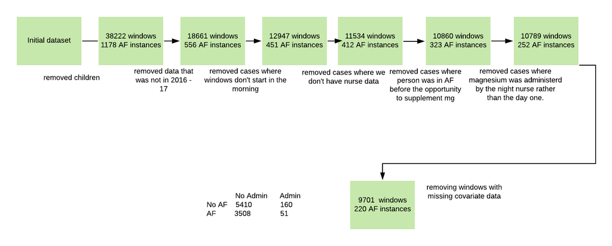

[output not shown]

There were 574 individual clinicians identified within this filtered dataset. The number of magnesium windows associated with each clinician ID ranged between 1 and 119 (median 4, IQR 1 - 26).

### Initial logistic regression to look at association between supplementation and AF.

The results of the regression are displayed below. There appears to be a negative relationship between mag supplementation and AF. So giving mg supplements is associated with a lower probability of getting AF. However, we can’t give this a causal interpretation.

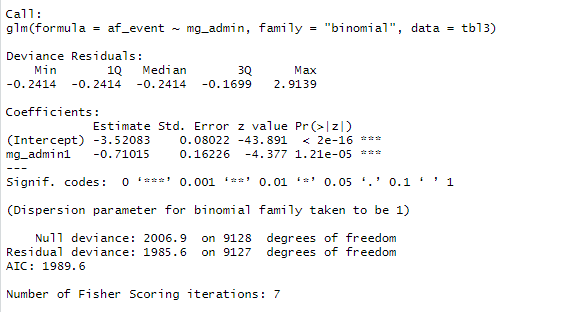

### Division of nurses into groups

We used a logistic regression to divide nurses into groups based on their probability of giving magneisum suppplements to patients at given levels of serum magnesium. The predicted probabilites fell into roughly 3 groups, which we classified as ‘always supplements’, ‘sometimes supplements’ and ‘never supplements’.

The grouping of nurses are shown below.

| names | numbers |
| --- | --- |
| Total nurses | 574 |
| Does not supplement frequently | 175 |
| Sometimes supplements | 327 |
| Frequently supplements | 72 |

The grouping of always, sometimes, never seems to be confirmed by comparing predictions for each combination of serum mg and nurse with the nurse groupings. This is displayed in the graph below.

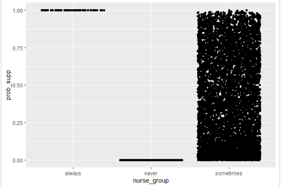

### Instrumental variable analysis.

We used a 2 stage least squares method to perform the instrumental variable analysis. We followed this tutorial. http://eclr.humanities.manchester.ac.uk/index.php/IV_in_R. Since the AER package can’t does not support logistic regression, I am also using the answer to this stack oververflow question to implement the logistic regression. https://stackoverflow.com/questions/30978507/two-stage-least-squares-regression-with-biomial-response-variable

We want to know if giving mg supplements prevents AF.

The first stage was to do a regression to predict magneisum supplementation based on nurse group. We then fed those predictions into a regression model with AF as the dependent variable and the prediction as the independent variable. I think?? using the prediction instead of the actual variable indicating if supplementation happened or not removes the variability which may have been caused by unobserved confounding.

The code and results are displayed below.

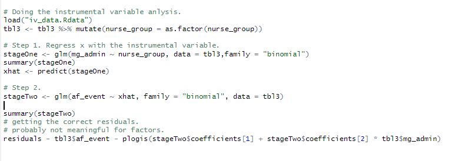

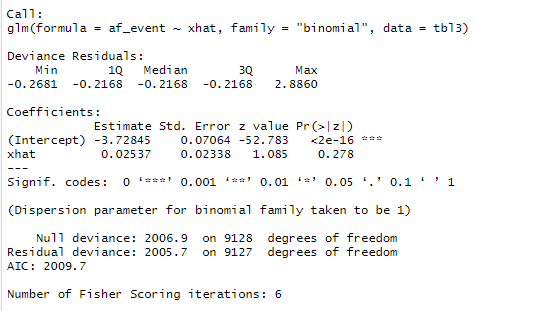

I think? this means that magnesuium supplementation does not have a causal effect on incidence of AF.

# Discussion

# Next Steps

- Evaluate pipeline integrity:
  - via lab meeting
  - create synthetic test data set
- Explore potential explanation for findings:
  - Cox PH model with additional covariates
  - Multilevel logistic regression to account for episode/pt differences
- Use step in serum magnesium administration to create regression discontinuity analysis
- Create stricter magnesium windows with attached nursing data and evaluate behaviour around magnesium administration as first step of IV analysis.